# INN_Learner_Notebook_Full_code_Mounika (1)

### Neural Network with Adam Optimizer and Dropout

```python
backend.clear_session()
#Fixing the seed for random number generators so that we can ensure we receive the same output everytime
np.random.seed(2)
random.seed(2)
tf.random.set_seed(2)
```

```python
#Initializing the neural network
model_2 = Sequential()
#Adding the input layer with 32 neurons and relu as activation function
model_2.add(Dense(32,activation='relu',input_dim = X_train.shape[1]))
# Adding dropout with ratio of 0.2
model_2.add(Dropout(0.2))
# Adding the first hidden layer with 16 neurons with relu as activation functions
model_2.add(Dense(16,activation='relu'))
# Adding dropout with ratio of 0.1
model_2.add(Dropout(0.1))
# Adding the second hidden layer with 8 neurons with relu as activation functions
model_2.add(Dense(8,activation='relu'))
# Adding the output layer
model_2.add(Dense(1, activation = 'sigmoid'))
```

```python
optimizer = tf.keras.optimizers.Adam(0.001)
metric = keras.metrics.Recall()
```

```python
#Let's compile the model with binary cross entropy as loss function and recall as the metric.
model_2.compile(loss='binary_crossentropy',optimizer=optimizer,metrics=[metric])
```

```python
# Summary of the model
model_2.summary()
```

```
Model: "sequential"
```

```
┏━━━━━━━━━━━━━━━━━━━━━━━━━━━━━━━━━━━━━━┳━━━━━━━━━━━━━━━━━━━━━━━━━━━━━┳━━━━━━━━━━━━━━━━━┓
┃ Layer (type)                         ┃ Output Shape                ┃         Param # ┃
┡━━━━━━━━━━━━━━━━━━━━━━━━━━━━━━━━━━━━━━╇━━━━━━━━━━━━━━━━━━━━━━━━━━━━━╇━━━━━━━━━━━━━━━━━┩
│ dense (Dense)                        │ (None, 32)                  │             384 │
├──────────────────────────────────────┼─────────────────────────────┼─────────────────┤
│ dropout (Dropout)                    │ (None, 32)                  │               0 │
├──────────────────────────────────────┼─────────────────────────────┼─────────────────┤
│ dense_1 (Dense)                      │ (None, 16)                  │             528 │
├──────────────────────────────────────┼─────────────────────────────┼─────────────────┤
│ dropout_1 (Dropout)                  │ (None, 16)                  │               0 │
├──────────────────────────────────────┼─────────────────────────────┼─────────────────┤
│ dense_2 (Dense)                      │ (None, 8)                   │             136 │
├──────────────────────────────────────┼─────────────────────────────┼─────────────────┤
│ dense_3 (Dense)                      │ (None, 1)                   │               9 │
└──────────────────────────────────────┴─────────────────────────────┴─────────────────┘
```

```
 Total params: 1,057 (4.13 KB)
```

```
 Trainable params: 1,057 (4.13 KB)
```

```
 Non-trainable params: 0 (0.00 B)
```

```python
#Fitting the ANN with batch_size = 32 and 100 epochs
history_2 = model_2.fit(
    X_train,y_train,
    batch_size=32,
    epochs=100,
    verbose=1,
    validation_data=(X_val,y_val)
)
```

```
154/154 ━━━━━━━━━━━━━━━━━━━━ 3s 5ms/step - loss: 0.5554 - recall: 0.0689 - val_loss: 0.4542 - val_recall: 0.0000e+00
154/154 ━━━━━━━━━━━━━━━━━━━━ 0s 3ms/step - loss: 0.4696 - recall: 0.0037 - val_loss: 0.4352 - val_recall: 0.0070
154/154 ━━━━━━━━━━━━━━━━━━━━ 0s 3ms/step - loss: 0.4507 - recall: 0.0564 - val_loss: 0.4271 - val_recall: 0.1215
154/154 ━━━━━━━━━━━━━━━━━━━━ 1s 3ms/step - loss: 0.4486 - recall: 0.1142 - val_loss: 0.4243 - val_recall: 0.1636
154/154 ━━━━━━━━━━━━━━━━━━━━ 1s 4ms/step - loss: 0.4438 - recall: 0.1435 - val_loss: 0.4196 - val_recall: 0.1846
154/154 ━━━━━━━━━━━━━━━━━━━━ 1s 3ms/step - loss: 0.4448 - recall: 0.1583 - val_loss: 0.4184 - val_recall: 0.2079
154/154 ━━━━━━━━━━━━━━━━━━━━ 0s 3ms/step - loss: 0.4375 - recall: 0.1932 - val_loss: 0.4160 - val_recall: 0.2407
154/154 ━━━━━━━━━━━━━━━━━━━━ 0s 3ms/step - loss: 0.4414 - recall: 0.1837 - val_loss: 0.4140 - val_recall: 0.2173
154/154 ━━━━━━━━━━━━━━━━━━━━ 1s 6ms/step - loss: 0.4336 - recall: 0.1773 - val_loss: 0.4104 - val_recall: 0.2640
154/154 ━━━━━━━━━━━━━━━━━━━━ 1s 5ms/step - loss: 0.4317 - recall: 0.2125 - val_loss: 0.4082 - val_recall: 0.2874
154/154 ━━━━━━━━━━━━━━━━━━━━ 1s 5ms/step - loss: 0.4278 - recall: 0.2225 - val_loss: 0.4060 - val_recall: 0.2967
154/154 ━━━━━━━━━━━━━━━━━━━━ 1s 5ms/step - loss: 0.4319 - recall: 0.2164 - val_loss: 0.4031 - val_recall: 0.2664
154/154 ━━━━━━━━━━━━━━━━━━━━ 1s 3ms/step - loss: 0.4208 - recall: 0.2356 - val_loss: 0.3995 - val_recall: 0.3154
154/154 ━━━━━━━━━━━━━━━━━━━━ 1s 3ms/step - loss: 0.4186 - recall: 0.2615 - val_loss: 0.3960 - val_recall: 0.3341
154/154 ━━━━━━━━━━━━━━━━━━━━ 0s 3ms/step - loss: 0.4193 - recall: 0.2347 - val_loss: 0.3930 - val_recall: 0.3832
154/154 ━━━━━━━━━━━━━━━━━━━━ 1s 3ms/step - loss: 0.4141 - recall: 0.2749 - val_loss: 0.3895 - val_recall: 0.3575
154/154 ━━━━━━━━━━━━━━━━━━━━ 1s 3ms/step - loss: 0.4108 - recall: 0.2970 - val_loss: 0.3865 - val_recall: 0.3458
154/154 ━━━━━━━━━━━━━━━━━━━━ 1s 3ms/step - loss: 0.4086 - recall: 0.2551 - val_loss: 0.3855 - val_recall: 0.3528
154/154 ━━━━━━━━━━━━━━━━━━━━ 1s 3ms/step - loss: 0.4051 - recall: 0.2874 - val_loss: 0.3818 - val_recall: 0.3645
154/154 ━━━━━━━━━━━━━━━━━━━━ 1s 3ms/step - loss: 0.4078 - recall: 0.2977 - val_loss: 0.3789 - val_recall: 0.3318
154/154 ━━━━━━━━━━━━━━━━━━━━ 1s 3ms/step - loss: 0.4010 - recall: 0.2891 - val_loss: 0.3771 - val_recall: 0.3505
154/154 ━━━━━━━━━━━━━━━━━━━━ 1s 3ms/step - loss: 0.3944 - recall: 0.3119 - val_loss: 0.3751 - val_recall: 0.3668
154/154 ━━━━━━━━━━━━━━━━━━━━ 1s 3ms/step - loss: 0.3997 - recall: 0.3148 - val_loss: 0.3725 - val_recall: 0.3949
154/154 ━━━━━━━━━━━━━━━━━━━━ 1s 3ms/step - loss: 0.3899 - recall: 0.3316 - val_loss: 0.3702 - val_recall: 0.3855
154/154 ━━━━━━━━━━━━━━━━━━━━ 1s 3ms/step - loss: 0.3947 - recall: 0.3333 - val_loss: 0.3685 - val_recall: 0.3925
154/154 ━━━━━━━━━━━━━━━━━━━━ 0s 3ms/step - loss: 0.3909 - recall: 0.3363 - val_loss: 0.3654 - val_recall: 0.4042
154/154 ━━━━━━━━━━━━━━━━━━━━ 1s 3ms/step - loss: 0.3808 - recall: 0.3426 - val_loss: 0.3625 - val_recall: 0.4206
154/154 ━━━━━━━━━━━━━━━━━━━━ 1s 3ms/step - loss: 0.3833 - recall: 0.3426 - val_loss: 0.3610 - val_recall: 0.4229
154/154 ━━━━━━━━━━━━━━━━━━━━ 0s 3ms/step - loss: 0.3802 - recall: 0.3643 - val_loss: 0.3576 - val_recall: 0.4346
154/154 ━━━━━━━━━━━━━━━━━━━━ 1s 5ms/step - loss: 0.3711 - recall: 0.3823 - val_loss: 0.3561 - val_recall: 0.4252
154/154 ━━━━━━━━━━━━━━━━━━━━ 1s 6ms/step - loss: 0.3739 - recall: 0.3639 - val_loss: 0.3537 - val_recall: 0.4346
154/154 ━━━━━━━━━━━━━━━━━━━━ 1s 5ms/step - loss: 0.3745 - recall: 0.3627 - val_loss: 0.3518 - val_recall: 0.4229
154/154 ━━━━━━━━━━━━━━━━━━━━ 1s 7ms/step - loss: 0.3740 - recall: 0.3655 - val_loss: 0.3513 - val_recall: 0.4486
154/154 ━━━━━━━━━━━━━━━━━━━━ 1s 6ms/step - loss: 0.3646 - recall: 0.4133 - val_loss: 0.3489 - val_recall: 0.4299
154/154 ━━━━━━━━━━━━━━━━━━━━ 1s 8ms/step - loss: 0.3693 - recall: 0.3550 - val_loss: 0.3469 - val_recall: 0.4626
154/154 ━━━━━━━━━━━━━━━━━━━━ 1s 5ms/step - loss: 0.3780 - recall: 0.3709 - val_loss: 0.3456 - val_recall: 0.4463
154/154 ━━━━━━━━━━━━━━━━━━━━ 1s 3ms/step - loss: 0.3629 - recall: 0.3957 - val_loss: 0.3449 - val_recall: 0.4556
154/154 ━━━━━━━━━━━━━━━━━━━━ 1s 3ms/step - loss: 0.3709 - recall: 0.3844 - val_loss: 0.3409 - val_recall: 0.4696
154/154 ━━━━━━━━━━━━━━━━━━━━ 0s 3ms/step - loss: 0.3714 - recall: 0.4047 - val_loss: 0.3418 - val_recall: 0.4790
154/154 ━━━━━━━━━━━━━━━━━━━━ 1s 3ms/step - loss: 0.3638 - recall: 0.3959 - val_loss: 0.3410 - val_recall: 0.4720
```

[output cut: 45 more lines]

```
154/154 ━━━━━━━━━━━━━━━━━━━━ 1s 3ms/step - loss: 0.3349 - recall: 0.4513 - val_loss: 0.3401 - val_recall: 0.5047
154/154 ━━━━━━━━━━━━━━━━━━━━ 1s 3ms/step - loss: 0.3341 - recall: 0.4719 - val_loss: 0.3398 - val_recall: 0.5000
154/154 ━━━━━━━━━━━━━━━━━━━━ 1s 4ms/step - loss: 0.3395 - recall: 0.4372 - val_loss: 0.3405 - val_recall: 0.4977
154/154 ━━━━━━━━━━━━━━━━━━━━ 1s 3ms/step - loss: 0.3460 - recall: 0.4355 - val_loss: 0.3396 - val_recall: 0.5047
154/154 ━━━━━━━━━━━━━━━━━━━━ 1s 3ms/step - loss: 0.3492 - recall: 0.4398 - val_loss: 0.3392 - val_recall: 0.5047
154/154 ━━━━━━━━━━━━━━━━━━━━ 1s 3ms/step - loss: 0.3351 - recall: 0.4468 - val_loss: 0.3389 - val_recall: 0.5047
154/154 ━━━━━━━━━━━━━━━━━━━━ 1s 3ms/step - loss: 0.3335 - recall: 0.4364 - val_loss: 0.3403 - val_recall: 0.4977
154/154 ━━━━━━━━━━━━━━━━━━━━ 1s 5ms/step - loss: 0.3381 - recall: 0.4398 - val_loss: 0.3429 - val_recall: 0.5023
154/154 ━━━━━━━━━━━━━━━━━━━━ 1s 5ms/step - loss: 0.3389 - recall: 0.4568 - val_loss: 0.3419 - val_recall: 0.5093
154/154 ━━━━━━━━━━━━━━━━━━━━ 1s 5ms/step - loss: 0.3355 - recall: 0.4418 - val_loss: 0.3409 - val_recall: 0.4860
154/154 ━━━━━━━━━━━━━━━━━━━━ 1s 6ms/step - loss: 0.3404 - recall: 0.4322 - val_loss: 0.3403 - val_recall: 0.5023
154/154 ━━━━━━━━━━━━━━━━━━━━ 1s 4ms/step - loss: 0.3343 - recall: 0.4441 - val_loss: 0.3403 - val_recall: 0.5000
154/154 ━━━━━━━━━━━━━━━━━━━━ 1s 4ms/step - loss: 0.3306 - recall: 0.4786 - val_loss: 0.3424 - val_recall: 0.5117
154/154 ━━━━━━━━━━━━━━━━━━━━ 1s 4ms/step - loss: 0.3371 - recall: 0.4559 - val_loss: 0.3411 - val_recall: 0.4860
154/154 ━━━━━━━━━━━━━━━━━━━━ 1s 8ms/step - loss: 0.3351 - recall: 0.4558 - val_loss: 0.3423 - val_recall: 0.5000
```

**Loss Function**

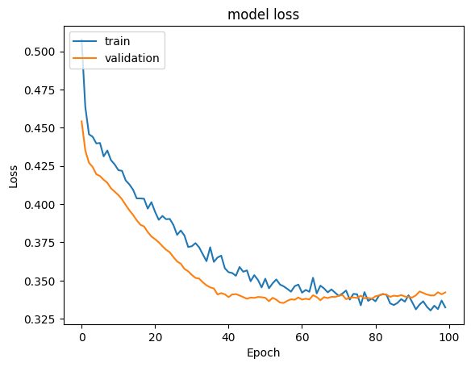

```python
#Plotting Train Loss vs Validation Loss
plt.plot(history_2.history['loss'])
plt.plot(history_2.history['val_loss'])
plt.title('model loss')
plt.ylabel('Loss')
plt.xlabel('Epoch')
plt.legend(['train', 'validation'], loc='upper left')
plt.show()
```

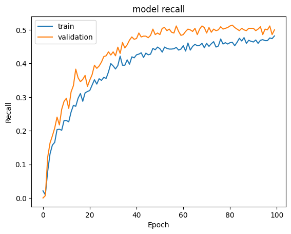

```python
#Plotting Train recall vs Validation recall
plt.plot(history_2.history['recall'])
plt.plot(history_2.history['val_recall'])
plt.title('model recall')
plt.ylabel('Recall')
plt.xlabel('Epoch')
plt.legend(['train', 'validation'], loc='upper left')
plt.show()
```

```python
#Predicting the results using best as a threshold
y_train_pred = model_2.predict(X_train)
y_train_pred = (y_train_pred > 0.5)
y_train_pred
```

```
154/154 ━━━━━━━━━━━━━━━━━━━━ 0s 2ms/step
```

```
array([[False],
       [False],
       [False],
       ...,
       [False],
       [False],
       [False]])
```

```python
#Predicting the results using 0.5 as the threshold.
y_val_pred = model_2.predict(X_val)
y_val_pred = (y_val_pred > 0.5)
y_val_pred
```

```
66/66 ━━━━━━━━━━━━━━━━━━━━ 0s 1ms/step
```

```
array([[False],
       [False],
       [False],
       ...,
       [False],
       [False],
       [False]])
```

```python
model_name = "Neural Network with Adam & Dropout"

train_metric_df.loc[model_name] = recall_score(y_train,y_train_pred)
valid_metric_df.loc[model_name] = recall_score(y_val,y_val_pred)
```

**Classification Report**

```python
#classification report
cr=classification_report(y_train,y_train_pred)
print(cr)
```

```
              precision    recall  f1-score   support

           0       0.88      0.98      0.93      3902
           1       0.84      0.49      0.62       998

    accuracy                           0.88      4900
   macro avg       0.86      0.73      0.77      4900
weighted avg       0.87      0.88      0.86      4900
```

```python
#classification report
cr = classification_report(y_val,y_val_pred)
print(cr)
```

```
              precision    recall  f1-score   support

           0       0.88      0.96      0.92      1672
           1       0.74      0.50      0.60       428

    accuracy                           0.86      2100
   macro avg       0.81      0.73      0.76      2100
weighted avg       0.85      0.86      0.85      2100
```

**Training Set:** The model performs well with high precision and recall for Class 0. However, for Class 1, the recall is lower, indicating that the model has difficulty identifying Class 1 instances.

**Confusion Matrix**

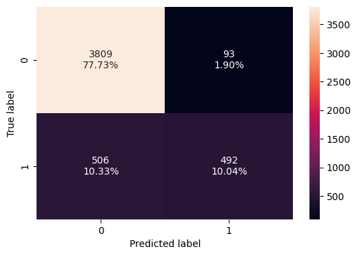

```python
#Calculating the confusion matrix
make_confusion_matrix(y_train, y_train_pred)
```

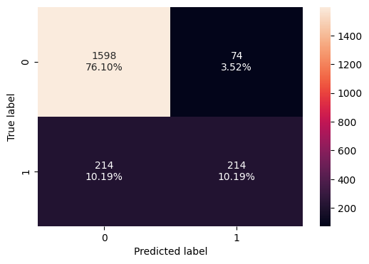

```python
#Calculating the confusion matrix
make_confusion_matrix(y_val,y_val_pred)
```

### Neural Network with Balanced Data (by applying SMOTE) and SGD Optimizer

**Let's apply SMOTE to balance the dataset and then perform hyperparameter tuning accordingly.**

```python
sm  = SMOTE(random_state=42)
X_train_smote, y_train_smote= sm.fit_resample(X_train,y_train)
print('After UpSampling, the shape of train_X: {}'.format(X_train_smote.shape))
print('After UpSampling, the shape of train_y: {} \n'.format(y_train_smote.shape))
```

```
After UpSampling, the shape of train_X: (7804, 11)
After UpSampling, the shape of train_y: (7804,)
```

Let's build a model with the balanced dataset

```python
backend.clear_session()
#Fixing the seed for random number generators so that we can ensure we receive the same output everytime
np.random.seed(2)
random.seed(2)
tf.random.set_seed(2)
```

```python
#Initializing the model
model_3 = Sequential()
# Adding input layer of 32 neurons with relu as activation function
model_3.add(Dense(32,activation='relu',input_dim = X_train_smote.shape[1]))
#Adding hidden layer with 16 neurons with relu as activation function
model_3.add(Dense(16,activation='relu'))
#Adding hidden layer with 8 neurons with relu as activation function
model_3.add(Dense(8,activation='relu'))
# Adding the output layer
model_3.add(Dense(1, activation = 'sigmoid'))
```

```python
optimizer = tf.keras.optimizers.SGD(0.001)

metric = keras.metrics.Recall()
```

```python
# Let's compile the model with binary cross entropy as loss function and recall as the metric
model_3.compile(loss='binary_crossentropy',optimizer=optimizer,metrics=[metric])
```

```python
model_3.summary()
```

```
Model: "sequential"
```

```
┏━━━━━━━━━━━━━━━━━━━━━━━━━━━━━━━━━━━━━━┳━━━━━━━━━━━━━━━━━━━━━━━━━━━━━┳━━━━━━━━━━━━━━━━━┓
┃ Layer (type)                         ┃ Output Shape                ┃         Param # ┃
┡━━━━━━━━━━━━━━━━━━━━━━━━━━━━━━━━━━━━━━╇━━━━━━━━━━━━━━━━━━━━━━━━━━━━━╇━━━━━━━━━━━━━━━━━┩
│ dense (Dense)                        │ (None, 32)                  │             384 │
├──────────────────────────────────────┼─────────────────────────────┼─────────────────┤
│ dense_1 (Dense)                      │ (None, 16)                  │             528 │
├──────────────────────────────────────┼─────────────────────────────┼─────────────────┤
│ dense_2 (Dense)                      │ (None, 8)                   │             136 │
├──────────────────────────────────────┼─────────────────────────────┼─────────────────┤
│ dense_3 (Dense)                      │ (None, 1)                   │               9 │
└──────────────────────────────────────┴─────────────────────────────┴─────────────────┘
```

```
 Total params: 1,057 (4.13 KB)
```

```
 Trainable params: 1,057 (4.13 KB)
```

```
 Non-trainable params: 0 (0.00 B)
```

```python
#Fitting the ANN
history_3 = model_3.fit(
    X_train_smote, y_train_smote,
    batch_size=32,
    epochs=100,
    verbose=1,
    validation_data = (X_val,y_val)
)
```

```
244/244 ━━━━━━━━━━━━━━━━━━━━ 2s 5ms/step - loss: 0.6998 - recall: 0.9464 - val_loss: 0.7384 - val_recall: 0.9369
244/244 ━━━━━━━━━━━━━━━━━━━━ 2s 2ms/step - loss: 0.6974 - recall: 0.9340 - val_loss: 0.7303 - val_recall: 0.9229
244/244 ━━━━━━━━━━━━━━━━━━━━ 1s 2ms/step - loss: 0.6955 - recall: 0.9251 - val_loss: 0.7233 - val_recall: 0.9136
244/244 ━━━━━━━━━━━━━━━━━━━━ 1s 2ms/step - loss: 0.6937 - recall: 0.9085 - val_loss: 0.7170 - val_recall: 0.8902
244/244 ━━━━━━━━━━━━━━━━━━━━ 1s 2ms/step - loss: 0.6921 - recall: 0.8869 - val_loss: 0.7107 - val_recall: 0.8551
244/244 ━━━━━━━━━━━━━━━━━━━━ 1s 2ms/step - loss: 0.6903 - recall: 0.8526 - val_loss: 0.7041 - val_recall: 0.7991
244/244 ━━━━━━━━━━━━━━━━━━━━ 1s 2ms/step - loss: 0.6882 - recall: 0.8048 - val_loss: 0.6961 - val_recall: 0.7360
244/244 ━━━━━━━━━━━━━━━━━━━━ 1s 2ms/step - loss: 0.6854 - recall: 0.7457 - val_loss: 0.6872 - val_recall: 0.6776
244/244 ━━━━━━━━━━━━━━━━━━━━ 1s 2ms/step - loss: 0.6822 - recall: 0.6973 - val_loss: 0.6784 - val_recall: 0.6355
244/244 ━━━━━━━━━━━━━━━━━━━━ 1s 2ms/step - loss: 0.6790 - recall: 0.6654 - val_loss: 0.6705 - val_recall: 0.6098
244/244 ━━━━━━━━━━━━━━━━━━━━ 1s 2ms/step - loss: 0.6760 - recall: 0.6438 - val_loss: 0.6636 - val_recall: 0.5981
244/244 ━━━━━━━━━━━━━━━━━━━━ 1s 2ms/step - loss: 0.6731 - recall: 0.6379 - val_loss: 0.6574 - val_recall: 0.6005
244/244 ━━━━━━━━━━━━━━━━━━━━ 1s 2ms/step - loss: 0.6702 - recall: 0.6410 - val_loss: 0.6517 - val_recall: 0.5958
244/244 ━━━━━━━━━━━━━━━━━━━━ 1s 2ms/step - loss: 0.6673 - recall: 0.6396 - val_loss: 0.6465 - val_recall: 0.5935
244/244 ━━━━━━━━━━━━━━━━━━━━ 1s 2ms/step - loss: 0.6643 - recall: 0.6387 - val_loss: 0.6415 - val_recall: 0.5958
244/244 ━━━━━━━━━━━━━━━━━━━━ 1s 4ms/step - loss: 0.6614 - recall: 0.6394 - val_loss: 0.6370 - val_recall: 0.6075
244/244 ━━━━━━━━━━━━━━━━━━━━ 1s 4ms/step - loss: 0.6585 - recall: 0.6369 - val_loss: 0.6328 - val_recall: 0.6075
244/244 ━━━━━━━━━━━━━━━━━━━━ 1s 4ms/step - loss: 0.6556 - recall: 0.6356 - val_loss: 0.6288 - val_recall: 0.6098
244/244 ━━━━━━━━━━━━━━━━━━━━ 1s 4ms/step - loss: 0.6527 - recall: 0.6303 - val_loss: 0.6253 - val_recall: 0.6075
244/244 ━━━━━━━━━━━━━━━━━━━━ 1s 3ms/step - loss: 0.6498 - recall: 0.6277 - val_loss: 0.6219 - val_recall: 0.6145
244/244 ━━━━━━━━━━━━━━━━━━━━ 1s 2ms/step - loss: 0.6469 - recall: 0.6305 - val_loss: 0.6186 - val_recall: 0.6192
244/244 ━━━━━━━━━━━━━━━━━━━━ 1s 2ms/step - loss: 0.6439 - recall: 0.6334 - val_loss: 0.6157 - val_recall: 0.6262
244/244 ━━━━━━━━━━━━━━━━━━━━ 1s 2ms/step - loss: 0.6409 - recall: 0.6345 - val_loss: 0.6130 - val_recall: 0.6285
244/244 ━━━━━━━━━━━━━━━━━━━━ 1s 2ms/step - loss: 0.6378 - recall: 0.6382 - val_loss: 0.6105 - val_recall: 0.6332
244/244 ━━━━━━━━━━━━━━━━━━━━ 1s 2ms/step - loss: 0.6347 - recall: 0.6423 - val_loss: 0.6083 - val_recall: 0.6332
244/244 ━━━━━━━━━━━━━━━━━━━━ 1s 2ms/step - loss: 0.6316 - recall: 0.6528 - val_loss: 0.6062 - val_recall: 0.6379
244/244 ━━━━━━━━━━━━━━━━━━━━ 1s 2ms/step - loss: 0.6284 - recall: 0.6554 - val_loss: 0.6043 - val_recall: 0.6449
244/244 ━━━━━━━━━━━━━━━━━━━━ 1s 2ms/step - loss: 0.6253 - recall: 0.6598 - val_loss: 0.6025 - val_recall: 0.6542
244/244 ━━━━━━━━━━━━━━━━━━━━ 1s 2ms/step - loss: 0.6222 - recall: 0.6644 - val_loss: 0.6006 - val_recall: 0.6565
244/244 ━━━━━━━━━━━━━━━━━━━━ 1s 2ms/step - loss: 0.6191 - recall: 0.6696 - val_loss: 0.5987 - val_recall: 0.6612
244/244 ━━━━━━━━━━━━━━━━━━━━ 1s 2ms/step - loss: 0.6160 - recall: 0.6770 - val_loss: 0.5966 - val_recall: 0.6659
244/244 ━━━━━━━━━━━━━━━━━━━━ 1s 2ms/step - loss: 0.6130 - recall: 0.6790 - val_loss: 0.5949 - val_recall: 0.6729
244/244 ━━━━━━━━━━━━━━━━━━━━ 1s 2ms/step - loss: 0.6099 - recall: 0.6831 - val_loss: 0.5932 - val_recall: 0.6729
244/244 ━━━━━━━━━━━━━━━━━━━━ 1s 2ms/step - loss: 0.6070 - recall: 0.6865 - val_loss: 0.5915 - val_recall: 0.6729
244/244 ━━━━━━━━━━━━━━━━━━━━ 1s 3ms/step - loss: 0.6041 - recall: 0.6900 - val_loss: 0.5898 - val_recall: 0.6752
244/244 ━━━━━━━━━━━━━━━━━━━━ 1s 3ms/step - loss: 0.6012 - recall: 0.6918 - val_loss: 0.5880 - val_recall: 0.6822
244/244 ━━━━━━━━━━━━━━━━━━━━ 1s 3ms/step - loss: 0.5985 - recall: 0.6938 - val_loss: 0.5861 - val_recall: 0.6846
244/244 ━━━━━━━━━━━━━━━━━━━━ 1s 5ms/step - loss: 0.5960 - recall: 0.6948 - val_loss: 0.5843 - val_recall: 0.6869
244/244 ━━━━━━━━━━━━━━━━━━━━ 1s 4ms/step - loss: 0.5935 - recall: 0.6950 - val_loss: 0.5831 - val_recall: 0.6846
244/244 ━━━━━━━━━━━━━━━━━━━━ 1s 2ms/step - loss: 0.5911 - recall: 0.6978 - val_loss: 0.5817 - val_recall: 0.6893
```

[output cut: 45 more lines]

```
244/244 ━━━━━━━━━━━━━━━━━━━━ 1s 2ms/step - loss: 0.5496 - recall: 0.7337 - val_loss: 0.5637 - val_recall: 0.7150
244/244 ━━━━━━━━━━━━━━━━━━━━ 1s 2ms/step - loss: 0.5492 - recall: 0.7350 - val_loss: 0.5636 - val_recall: 0.7126
244/244 ━━━━━━━━━━━━━━━━━━━━ 1s 2ms/step - loss: 0.5489 - recall: 0.7348 - val_loss: 0.5633 - val_recall: 0.7126
244/244 ━━━━━━━━━━━━━━━━━━━━ 1s 2ms/step - loss: 0.5486 - recall: 0.7346 - val_loss: 0.5631 - val_recall: 0.7150
244/244 ━━━━━━━━━━━━━━━━━━━━ 1s 2ms/step - loss: 0.5482 - recall: 0.7347 - val_loss: 0.5629 - val_recall: 0.7150
244/244 ━━━━━━━━━━━━━━━━━━━━ 2s 4ms/step - loss: 0.5479 - recall: 0.7350 - val_loss: 0.5629 - val_recall: 0.7150
244/244 ━━━━━━━━━━━━━━━━━━━━ 1s 4ms/step - loss: 0.5476 - recall: 0.7353 - val_loss: 0.5627 - val_recall: 0.7150
244/244 ━━━━━━━━━━━━━━━━━━━━ 1s 4ms/step - loss: 0.5473 - recall: 0.7364 - val_loss: 0.5626 - val_recall: 0.7150
244/244 ━━━━━━━━━━━━━━━━━━━━ 1s 2ms/step - loss: 0.5470 - recall: 0.7372 - val_loss: 0.5625 - val_recall: 0.7173
244/244 ━━━━━━━━━━━━━━━━━━━━ 1s 2ms/step - loss: 0.5467 - recall: 0.7379 - val_loss: 0.5624 - val_recall: 0.7173
244/244 ━━━━━━━━━━━━━━━━━━━━ 1s 2ms/step - loss: 0.5464 - recall: 0.7391 - val_loss: 0.5623 - val_recall: 0.7173
244/244 ━━━━━━━━━━━━━━━━━━━━ 1s 2ms/step - loss: 0.5461 - recall: 0.7401 - val_loss: 0.5622 - val_recall: 0.7150
244/244 ━━━━━━━━━━━━━━━━━━━━ 1s 2ms/step - loss: 0.5458 - recall: 0.7412 - val_loss: 0.5621 - val_recall: 0.7150
244/244 ━━━━━━━━━━━━━━━━━━━━ 1s 2ms/step - loss: 0.5455 - recall: 0.7410 - val_loss: 0.5620 - val_recall: 0.7150
244/244 ━━━━━━━━━━━━━━━━━━━━ 1s 2ms/step - loss: 0.5452 - recall: 0.7412 - val_loss: 0.5620 - val_recall: 0.7173
```

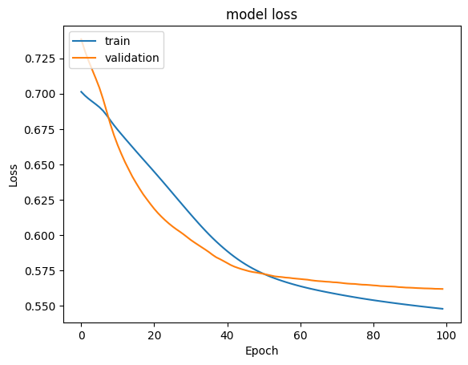

```python
#Plotting Train Loss vs Validation Loss
plt.plot(history_3.history['loss'])
plt.plot(history_3.history['val_loss'])
plt.title('model loss')
plt.ylabel('Loss')
plt.xlabel('Epoch')
plt.legend(['train', 'validation'], loc='upper left')
plt.show()
```

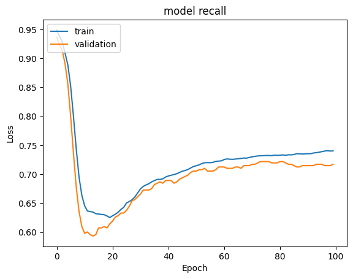

```python
#Plotting Train recall vs Validation recall
plt.plot(history_3.history['recall'])
plt.plot(history_3.history['val_recall'])
plt.title('model recall')
plt.ylabel('Loss')
plt.xlabel('Epoch')
plt.legend(['train', 'validation'], loc='upper left')
plt.show()
```

```python
y_train_pred = model_3.predict(X_train_smote)
#Predicting the results using 0.5 as the threshold
y_train_pred = (y_train_pred > 0.5)
y_train_pred
```

```
244/244 ━━━━━━━━━━━━━━━━━━━━ 0s 1ms/step
```

```
array([[False],
       [False],
       [False],
       ...,
       [ True],
       [ True],
       [ True]])
```

```python
y_val_pred = model_3.predict(X_val)
#Predicting the results using 0.5 as the threshold
y_val_pred = (y_val_pred > 0.5)
y_val_pred
```

```
66/66 ━━━━━━━━━━━━━━━━━━━━ 0s 1ms/step
```

```
array([[False],
       [False],
       [ True],
       ...,
       [False],
       [ True],
       [False]])
```

```python
model_name = "Neural Network with SMOTE & SGD"

train_metric_df.loc[model_name] = recall_score(y_train_smote,y_train_pred)
valid_metric_df.loc[model_name] = recall_score(y_val,y_val_pred)
```

**Classification Report**

```python
cr=classification_report(y_train_smote,y_train_pred)
print(cr)
```

```
              precision    recall  f1-score   support

           0       0.73      0.73      0.73      3902
           1       0.73      0.74      0.73      3902

    accuracy                           0.73      7804
   macro avg       0.73      0.73      0.73      7804
weighted avg       0.73      0.73      0.73      7804
```

```python
cr=classification_report(y_val,y_val_pred)
print(cr)
```

```
              precision    recall  f1-score   support

           0       0.91      0.72      0.80      1672
           1       0.39      0.72      0.51       428

    accuracy                           0.72      2100
   macro avg       0.65      0.72      0.65      2100
weighted avg       0.80      0.72      0.74      2100
```

**Training Set:** The model performs equally well for both classes with balanced precision, recall, and F1-scores. The overall accuracy is 73%.

**Validation Set:** The model shows strong precision for Class 0 but significantly weaker precision for Class 1. The recall for Class 1 is much better (72%) compared to its precision (39%), indicating that while many Class 1 instances are identified, they are often misclassified. Overall, the model’s performance on the validation set suggests that while it performs well for the majority class (Class 0), it struggles with the minority class (Class 1). You might consider further adjustments, such as additional hyperparameter tuning, class weighting, or different resampling techniques to improve the model's performance, especially for the minority class.

**Confusion Matrix**

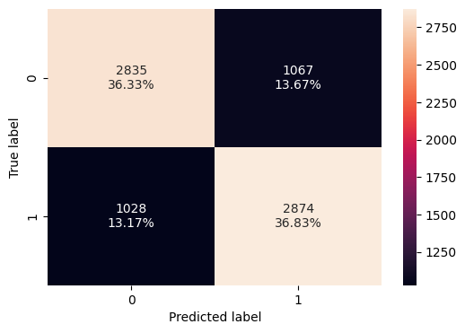

```python
#Calculating the confusion matrix
make_confusion_matrix(y_train_smote, y_train_pred)
```

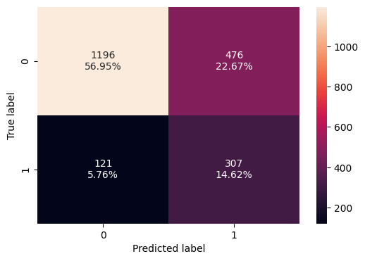

```python
#Calculating the confusion matrix

make_confusion_matrix(y_val,y_val_pred)
```

### Neural Network with Balanced Data (by applying SMOTE) and Adam Optimizer

```python
backend.clear_session()
#Fixing the seed for random number generators so that we can ensure we receive the same output everytime
np.random.seed(2)
random.seed(2)
tf.random.set_seed(2)
```

```python
#Initializing the model
model_4 = Sequential()
# Adding input layer of 32 neurons with relu as activation function
model_4.add(Dense(32,activation='relu',input_dim = X_train_smote.shape[1]))
#Adding hidden layer with 16 neurons with relu as activation function
model_4.add(Dense(16,activation='relu'))
#Adding hidden layer with 8 neurons with relu as activation function
model_4.add(Dense(8,activation='relu'))
# Adding the output layer
model_4.add(Dense(1, activation = 'sigmoid'))
```

```python
model_4.summary()
```

```
Model: "sequential"
```

```
┏━━━━━━━━━━━━━━━━━━━━━━━━━━━━━━━━━━━━━━┳━━━━━━━━━━━━━━━━━━━━━━━━━━━━━┳━━━━━━━━━━━━━━━━━┓
┃ Layer (type)                         ┃ Output Shape                ┃         Param # ┃
┡━━━━━━━━━━━━━━━━━━━━━━━━━━━━━━━━━━━━━━╇━━━━━━━━━━━━━━━━━━━━━━━━━━━━━╇━━━━━━━━━━━━━━━━━┩
│ dense (Dense)                        │ (None, 32)                  │             384 │
├──────────────────────────────────────┼─────────────────────────────┼─────────────────┤
│ dense_1 (Dense)                      │ (None, 16)                  │             528 │
├──────────────────────────────────────┼─────────────────────────────┼─────────────────┤
│ dense_2 (Dense)                      │ (None, 8)                   │             136 │
├──────────────────────────────────────┼─────────────────────────────┼─────────────────┤
│ dense_3 (Dense)                      │ (None, 1)                   │               9 │
└──────────────────────────────────────┴─────────────────────────────┴─────────────────┘
```

```
 Total params: 1,057 (4.13 KB)
```

```
 Trainable params: 1,057 (4.13 KB)
```

```
 Non-trainable params: 0 (0.00 B)
```

```python
optimizer = tf.keras.optimizers.Adam()
metric = keras.metrics.Recall()
```

```python
# Let's compile the model with binary cross entropy as loss function and recall as the metric
model_4.compile(loss='binary_crossentropy',optimizer=optimizer,metrics=[metric])
```

```python
model_4.summary()
```

```
Model: "sequential"
```

```
┏━━━━━━━━━━━━━━━━━━━━━━━━━━━━━━━━━━━━━━┳━━━━━━━━━━━━━━━━━━━━━━━━━━━━━┳━━━━━━━━━━━━━━━━━┓
┃ Layer (type)                         ┃ Output Shape                ┃         Param # ┃
┡━━━━━━━━━━━━━━━━━━━━━━━━━━━━━━━━━━━━━━╇━━━━━━━━━━━━━━━━━━━━━━━━━━━━━╇━━━━━━━━━━━━━━━━━┩
│ dense (Dense)                        │ (None, 32)                  │             384 │
├──────────────────────────────────────┼─────────────────────────────┼─────────────────┤
│ dense_1 (Dense)                      │ (None, 16)                  │             528 │
├──────────────────────────────────────┼─────────────────────────────┼─────────────────┤
│ dense_2 (Dense)                      │ (None, 8)                   │             136 │
├──────────────────────────────────────┼─────────────────────────────┼─────────────────┤
│ dense_3 (Dense)                      │ (None, 1)                   │               9 │
└──────────────────────────────────────┴─────────────────────────────┴─────────────────┘
```

```
 Total params: 1,057 (4.13 KB)
```

```
 Trainable params: 1,057 (4.13 KB)
```

```
 Non-trainable params: 0 (0.00 B)
```

```python
#Fitting the ANN

history_4 = model_4.fit(
    X_train_smote,y_train_smote,
    batch_size=32,
    epochs=100,
    verbose=1,
    validation_data = (X_val,y_val)
)
```

```
244/244 ━━━━━━━━━━━━━━━━━━━━ 2s 4ms/step - loss: 0.6443 - recall: 0.7723 - val_loss: 0.5518 - val_recall: 0.7033
244/244 ━━━━━━━━━━━━━━━━━━━━ 1s 3ms/step - loss: 0.5517 - recall: 0.7436 - val_loss: 0.5478 - val_recall: 0.7243
244/244 ━━━━━━━━━━━━━━━━━━━━ 1s 2ms/step - loss: 0.5322 - recall: 0.7583 - val_loss: 0.5336 - val_recall: 0.7336
244/244 ━━━━━━━━━━━━━━━━━━━━ 1s 2ms/step - loss: 0.5083 - recall: 0.7691 - val_loss: 0.5179 - val_recall: 0.7430
244/244 ━━━━━━━━━━━━━━━━━━━━ 1s 3ms/step - loss: 0.4865 - recall: 0.7782 - val_loss: 0.5069 - val_recall: 0.7500
244/244 ━━━━━━━━━━━━━━━━━━━━ 1s 2ms/step - loss: 0.4677 - recall: 0.7855 - val_loss: 0.4897 - val_recall: 0.7383
244/244 ━━━━━━━━━━━━━━━━━━━━ 1s 3ms/step - loss: 0.4541 - recall: 0.7891 - val_loss: 0.4802 - val_recall: 0.7430
244/244 ━━━━━━━━━━━━━━━━━━━━ 1s 3ms/step - loss: 0.4437 - recall: 0.7956 - val_loss: 0.4724 - val_recall: 0.7453
244/244 ━━━━━━━━━━━━━━━━━━━━ 1s 4ms/step - loss: 0.4355 - recall: 0.7976 - val_loss: 0.4699 - val_recall: 0.7383
244/244 ━━━━━━━━━━━━━━━━━━━━ 1s 4ms/step - loss: 0.4280 - recall: 0.8010 - val_loss: 0.4691 - val_recall: 0.7407
244/244 ━━━━━━━━━━━━━━━━━━━━ 2s 6ms/step - loss: 0.4212 - recall: 0.8086 - val_loss: 0.4669 - val_recall: 0.7360
244/244 ━━━━━━━━━━━━━━━━━━━━ 2s 3ms/step - loss: 0.4152 - recall: 0.8110 - val_loss: 0.4659 - val_recall: 0.7336
244/244 ━━━━━━━━━━━━━━━━━━━━ 1s 2ms/step - loss: 0.4102 - recall: 0.8196 - val_loss: 0.4684 - val_recall: 0.7360
244/244 ━━━━━━━━━━━━━━━━━━━━ 1s 2ms/step - loss: 0.4055 - recall: 0.8233 - val_loss: 0.4698 - val_recall: 0.7407
244/244 ━━━━━━━━━━━━━━━━━━━━ 1s 3ms/step - loss: 0.4015 - recall: 0.8249 - val_loss: 0.4711 - val_recall: 0.7336
244/244 ━━━━━━━━━━━━━━━━━━━━ 1s 2ms/step - loss: 0.3975 - recall: 0.8270 - val_loss: 0.4749 - val_recall: 0.7336
244/244 ━━━━━━━━━━━━━━━━━━━━ 1s 2ms/step - loss: 0.3943 - recall: 0.8277 - val_loss: 0.4777 - val_recall: 0.7360
244/244 ━━━━━━━━━━━━━━━━━━━━ 1s 3ms/step - loss: 0.3916 - recall: 0.8341 - val_loss: 0.4819 - val_recall: 0.7383
244/244 ━━━━━━━━━━━━━━━━━━━━ 1s 2ms/step - loss: 0.3890 - recall: 0.8370 - val_loss: 0.4822 - val_recall: 0.7453
244/244 ━━━━━━━━━━━━━━━━━━━━ 1s 3ms/step - loss: 0.3861 - recall: 0.8385 - val_loss: 0.4846 - val_recall: 0.7407
244/244 ━━━━━━━━━━━━━━━━━━━━ 1s 2ms/step - loss: 0.3841 - recall: 0.8394 - val_loss: 0.4869 - val_recall: 0.7407
244/244 ━━━━━━━━━━━━━━━━━━━━ 1s 3ms/step - loss: 0.3821 - recall: 0.8386 - val_loss: 0.4878 - val_recall: 0.7430
244/244 ━━━━━━━━━━━━━━━━━━━━ 2s 5ms/step - loss: 0.3803 - recall: 0.8407 - val_loss: 0.4883 - val_recall: 0.7453
244/244 ━━━━━━━━━━━━━━━━━━━━ 1s 5ms/step - loss: 0.3785 - recall: 0.8435 - val_loss: 0.4888 - val_recall: 0.7523
244/244 ━━━━━━━━━━━━━━━━━━━━ 1s 5ms/step - loss: 0.3770 - recall: 0.8451 - val_loss: 0.4892 - val_recall: 0.7477
244/244 ━━━━━━━━━━━━━━━━━━━━ 1s 3ms/step - loss: 0.3755 - recall: 0.8470 - val_loss: 0.4908 - val_recall: 0.7500
244/244 ━━━━━━━━━━━━━━━━━━━━ 1s 2ms/step - loss: 0.3742 - recall: 0.8467 - val_loss: 0.4888 - val_recall: 0.7477
244/244 ━━━━━━━━━━━━━━━━━━━━ 1s 2ms/step - loss: 0.3727 - recall: 0.8468 - val_loss: 0.4911 - val_recall: 0.7453
244/244 ━━━━━━━━━━━━━━━━━━━━ 1s 2ms/step - loss: 0.3715 - recall: 0.8502 - val_loss: 0.4929 - val_recall: 0.7477
244/244 ━━━━━━━━━━━━━━━━━━━━ 1s 3ms/step - loss: 0.3702 - recall: 0.8479 - val_loss: 0.4961 - val_recall: 0.7477
244/244 ━━━━━━━━━━━━━━━━━━━━ 1s 3ms/step - loss: 0.3693 - recall: 0.8512 - val_loss: 0.4977 - val_recall: 0.7523
244/244 ━━━━━━━━━━━━━━━━━━━━ 1s 2ms/step - loss: 0.3685 - recall: 0.8510 - val_loss: 0.4990 - val_recall: 0.7500
244/244 ━━━━━━━━━━━━━━━━━━━━ 1s 3ms/step - loss: 0.3674 - recall: 0.8532 - val_loss: 0.5002 - val_recall: 0.7547
244/244 ━━━━━━━━━━━━━━━━━━━━ 1s 2ms/step - loss: 0.3665 - recall: 0.8534 - val_loss: 0.5002 - val_recall: 0.7523
244/244 ━━━━━━━━━━━━━━━━━━━━ 1s 3ms/step - loss: 0.3656 - recall: 0.8552 - val_loss: 0.5010 - val_recall: 0.7523
244/244 ━━━━━━━━━━━━━━━━━━━━ 2s 4ms/step - loss: 0.3648 - recall: 0.8554 - val_loss: 0.5036 - val_recall: 0.7523
244/244 ━━━━━━━━━━━━━━━━━━━━ 1s 4ms/step - loss: 0.3641 - recall: 0.8573 - val_loss: 0.5048 - val_recall: 0.7500
244/244 ━━━━━━━━━━━━━━━━━━━━ 1s 4ms/step - loss: 0.3633 - recall: 0.8577 - val_loss: 0.5066 - val_recall: 0.7500
244/244 ━━━━━━━━━━━━━━━━━━━━ 1s 4ms/step - loss: 0.3623 - recall: 0.8569 - val_loss: 0.5074 - val_recall: 0.7523
244/244 ━━━━━━━━━━━━━━━━━━━━ 1s 3ms/step - loss: 0.3612 - recall: 0.8562 - val_loss: 0.5085 - val_recall: 0.7523
```

[output cut: 45 more lines]

```
244/244 ━━━━━━━━━━━━━━━━━━━━ 1s 2ms/step - loss: 0.3298 - recall: 0.8715 - val_loss: 0.5660 - val_recall: 0.7290
244/244 ━━━━━━━━━━━━━━━━━━━━ 1s 3ms/step - loss: 0.3291 - recall: 0.8750 - val_loss: 0.5669 - val_recall: 0.7290
244/244 ━━━━━━━━━━━━━━━━━━━━ 1s 3ms/step - loss: 0.3290 - recall: 0.8742 - val_loss: 0.5674 - val_recall: 0.7266
244/244 ━━━━━━━━━━━━━━━━━━━━ 1s 2ms/step - loss: 0.3284 - recall: 0.8748 - val_loss: 0.5689 - val_recall: 0.7383
244/244 ━━━━━━━━━━━━━━━━━━━━ 2s 4ms/step - loss: 0.3281 - recall: 0.8743 - val_loss: 0.5692 - val_recall: 0.7360
244/244 ━━━━━━━━━━━━━━━━━━━━ 1s 5ms/step - loss: 0.3270 - recall: 0.8744 - val_loss: 0.5708 - val_recall: 0.7383
244/244 ━━━━━━━━━━━━━━━━━━━━ 1s 5ms/step - loss: 0.3273 - recall: 0.8741 - val_loss: 0.5727 - val_recall: 0.7336
244/244 ━━━━━━━━━━━━━━━━━━━━ 1s 5ms/step - loss: 0.3266 - recall: 0.8753 - val_loss: 0.5753 - val_recall: 0.7360
244/244 ━━━━━━━━━━━━━━━━━━━━ 1s 2ms/step - loss: 0.3267 - recall: 0.8738 - val_loss: 0.5740 - val_recall: 0.7360
244/244 ━━━━━━━━━━━━━━━━━━━━ 1s 2ms/step - loss: 0.3259 - recall: 0.8757 - val_loss: 0.5782 - val_recall: 0.7407
244/244 ━━━━━━━━━━━━━━━━━━━━ 1s 2ms/step - loss: 0.3257 - recall: 0.8763 - val_loss: 0.5776 - val_recall: 0.7407
244/244 ━━━━━━━━━━━━━━━━━━━━ 1s 2ms/step - loss: 0.3254 - recall: 0.8750 - val_loss: 0.5801 - val_recall: 0.7407
244/244 ━━━━━━━━━━━━━━━━━━━━ 1s 3ms/step - loss: 0.3251 - recall: 0.8752 - val_loss: 0.5822 - val_recall: 0.7407
244/244 ━━━━━━━━━━━━━━━━━━━━ 1s 3ms/step - loss: 0.3245 - recall: 0.8751 - val_loss: 0.5813 - val_recall: 0.7407
244/244 ━━━━━━━━━━━━━━━━━━━━ 1s 3ms/step - loss: 0.3237 - recall: 0.8763 - val_loss: 0.5795 - val_recall: 0.7430
```

**Loss Function**

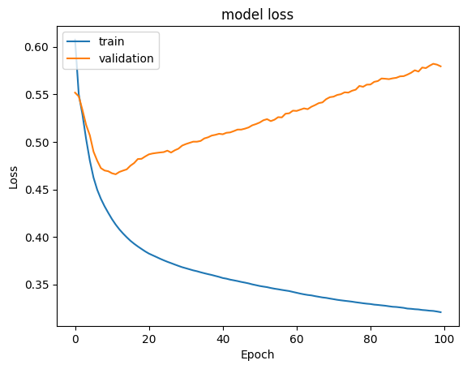

```python
#Plotting Train Loss vs Validation Loss
plt.plot(history_4.history['loss'])
plt.plot(history_4.history['val_loss'])
plt.title('model loss')
plt.ylabel('Loss')
plt.xlabel('Epoch')
plt.legend(['train', 'validation'], loc='upper left')
plt.show()
```

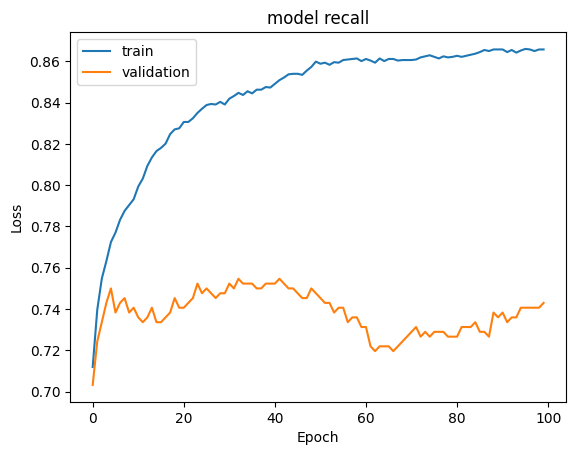

```python
#Plotting Train recall vs Validation recall
plt.plot(history_4.history['recall'])
plt.plot(history_4.history['val_recall'])
plt.title('model recall')
plt.ylabel('Loss')
plt.xlabel('Epoch')
plt.legend(['train', 'validation'], loc='upper left')
plt.show()
```

```python
y_train_pred = model_4.predict(X_train_smote)
#Predicting the results using 0.5 as the threshold
y_train_pred = (y_train_pred > 0.5)
y_train_pred
```

```
244/244 ━━━━━━━━━━━━━━━━━━━━ 1s 2ms/step
```

```
array([[False],
       [False],
       [False],
       ...,
       [ True],
       [ True],
       [ True]])
```

```python
y_val_pred = model_4.predict(X_val)
#Predicting the results using 0.5 as the threshold
y_val_pred = (y_val_pred > 0.5)
y_val_pred
```

```
66/66 ━━━━━━━━━━━━━━━━━━━━ 0s 1ms/step
```

```
array([[False],
       [False],
       [False],
       ...,
       [False],
       [ True],
       [ True]])
```

```python
model_name = "Neural Network with SMOTE & Adam"

train_metric_df.loc[model_name] = recall_score(y_train_smote,y_train_pred)
valid_metric_df.loc[model_name] = recall_score(y_val,y_val_pred)
```

**Classification Report**

```python
cr=classification_report(y_train_smote,y_train_pred)
print(cr)
```

```
              precision    recall  f1-score   support

           0       0.89      0.82      0.86      3902
           1       0.84      0.90      0.87      3902

    accuracy                           0.86      7804
   macro avg       0.86      0.86      0.86      7804
weighted avg       0.86      0.86      0.86      7804
```

```python
cr=classification_report(y_val,y_val_pred)
print(cr)
```

```
              precision    recall  f1-score   support

           0       0.92      0.77      0.84      1672
           1       0.45      0.74      0.56       428

    accuracy                           0.76      2100
   macro avg       0.69      0.76      0.70      2100
weighted avg       0.83      0.76      0.78      2100
```

**Training Set:** The model performs well with high precision, recall, and F1-scores for both classes, achieving an accuracy of 86%. This indicates good performance and balance on the training data.

Overall, the model demonstrates strong performance on the training set but faces challenges with Class 1 precision on the validation set.

**Confusion Matrix**

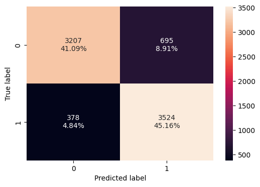

```python
#Calculating the confusion matrix
make_confusion_matrix(y_train_smote, y_train_pred)
```

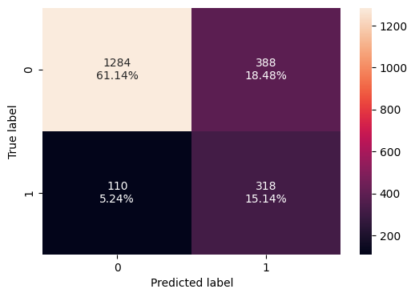

```python
#Calculating the confusion matrix
make_confusion_matrix(y_val,y_val_pred)
```

### Neural Network with Balanced Data (by applying SMOTE), Adam Optimizer, and Dropout

```python
backend.clear_session()
#Fixing the seed for random number generators so that we can ensure we receive the same output everytime
np.random.seed(2)
random.seed(2)
tf.random.set_seed(2)
```

```python
#Initializing the model
model_5 = Sequential()
# Adding input layer of 32 neurons with relu as activation function
model_5.add(Dense(32,activation='relu',input_dim = X_train_smote.shape[1]))
# Adding the dropout
model_5.add(Dropout(0.2))
# Adding hidden layer with 16 neurons with relu as activation function
model_5.add(Dense(16,activation='relu'))
# Adding the dropout
model_5.add(Dropout(0.1))
# Adding hidden layer with 8 neurons with relu as activation function
model_5.add(Dense(8,activation='relu'))
# Adding the output layer
model_5.add(Dense(1, activation = 'sigmoid'))
```

```python
optimizer = tf.keras.optimizers.Adam(0.01)
metric = keras.metrics.Recall()
```

```python
# Let's compile the model with binary cross entropy as loss function and recall as the metric
model_5.compile(loss='binary_crossentropy',optimizer=optimizer,metrics=[metric])
```

```python
model_5.summary()
```

```
Model: "sequential"
```

```
┏━━━━━━━━━━━━━━━━━━━━━━━━━━━━━━━━━━━━━━┳━━━━━━━━━━━━━━━━━━━━━━━━━━━━━┳━━━━━━━━━━━━━━━━━┓
┃ Layer (type)                         ┃ Output Shape                ┃         Param # ┃
┡━━━━━━━━━━━━━━━━━━━━━━━━━━━━━━━━━━━━━━╇━━━━━━━━━━━━━━━━━━━━━━━━━━━━━╇━━━━━━━━━━━━━━━━━┩
│ dense (Dense)                        │ (None, 32)                  │             384 │
├──────────────────────────────────────┼─────────────────────────────┼─────────────────┤
│ dropout (Dropout)                    │ (None, 32)                  │               0 │
├──────────────────────────────────────┼─────────────────────────────┼─────────────────┤
│ dense_1 (Dense)                      │ (None, 16)                  │             528 │
├──────────────────────────────────────┼─────────────────────────────┼─────────────────┤
│ dropout_1 (Dropout)                  │ (None, 16)                  │               0 │
├──────────────────────────────────────┼─────────────────────────────┼─────────────────┤
│ dense_2 (Dense)                      │ (None, 8)                   │             136 │
├──────────────────────────────────────┼─────────────────────────────┼─────────────────┤
│ dense_3 (Dense)                      │ (None, 1)                   │               9 │
└──────────────────────────────────────┴─────────────────────────────┴─────────────────┘
```

```
 Total params: 1,057 (4.13 KB)
```

```
 Trainable params: 1,057 (4.13 KB)
```

```
 Non-trainable params: 0 (0.00 B)
```

```python
history_5 = model_5.fit(
    X_train_smote,y_train_smote,
    batch_size=32,
    epochs=100,
    verbose=1,
    validation_data = (X_val,y_val))
```

```
244/244 ━━━━━━━━━━━━━━━━━━━━ 3s 4ms/step - loss: 0.6014 - recall: 0.7181 - val_loss: 0.5181 - val_recall: 0.6822
244/244 ━━━━━━━━━━━━━━━━━━━━ 1s 3ms/step - loss: 0.5235 - recall: 0.7396 - val_loss: 0.5142 - val_recall: 0.6612
244/244 ━━━━━━━━━━━━━━━━━━━━ 1s 3ms/step - loss: 0.5031 - recall: 0.7370 - val_loss: 0.5025 - val_recall: 0.7336
244/244 ━━━━━━━━━━━━━━━━━━━━ 1s 3ms/step - loss: 0.4791 - recall: 0.7707 - val_loss: 0.4541 - val_recall: 0.6986
244/244 ━━━━━━━━━━━━━━━━━━━━ 1s 3ms/step - loss: 0.4648 - recall: 0.7607 - val_loss: 0.4756 - val_recall: 0.7710
244/244 ━━━━━━━━━━━━━━━━━━━━ 1s 3ms/step - loss: 0.4515 - recall: 0.7825 - val_loss: 0.4602 - val_recall: 0.7360
244/244 ━━━━━━━━━━━━━━━━━━━━ 2s 4ms/step - loss: 0.4450 - recall: 0.7876 - val_loss: 0.4750 - val_recall: 0.7523
244/244 ━━━━━━━━━━━━━━━━━━━━ 2s 5ms/step - loss: 0.4492 - recall: 0.7897 - val_loss: 0.4852 - val_recall: 0.7780
244/244 ━━━━━━━━━━━━━━━━━━━━ 2s 6ms/step - loss: 0.4409 - recall: 0.7992 - val_loss: 0.4779 - val_recall: 0.7453
244/244 ━━━━━━━━━━━━━━━━━━━━ 2s 5ms/step - loss: 0.4360 - recall: 0.7948 - val_loss: 0.4805 - val_recall: 0.7407
244/244 ━━━━━━━━━━━━━━━━━━━━ 2s 2ms/step - loss: 0.4364 - recall: 0.8019 - val_loss: 0.4667 - val_recall: 0.7523
244/244 ━━━━━━━━━━━━━━━━━━━━ 1s 3ms/step - loss: 0.4423 - recall: 0.7861 - val_loss: 0.4573 - val_recall: 0.7383
244/244 ━━━━━━━━━━━━━━━━━━━━ 1s 2ms/step - loss: 0.4344 - recall: 0.8027 - val_loss: 0.4740 - val_recall: 0.7850
244/244 ━━━━━━━━━━━━━━━━━━━━ 1s 3ms/step - loss: 0.4310 - recall: 0.8102 - val_loss: 0.4800 - val_recall: 0.7710
244/244 ━━━━━━━━━━━━━━━━━━━━ 1s 3ms/step - loss: 0.4362 - recall: 0.7999 - val_loss: 0.4877 - val_recall: 0.7570
244/244 ━━━━━━━━━━━━━━━━━━━━ 1s 3ms/step - loss: 0.4333 - recall: 0.8019 - val_loss: 0.4804 - val_recall: 0.7500
244/244 ━━━━━━━━━━━━━━━━━━━━ 1s 3ms/step - loss: 0.4339 - recall: 0.8006 - val_loss: 0.4880 - val_recall: 0.7664
244/244 ━━━━━━━━━━━━━━━━━━━━ 1s 3ms/step - loss: 0.4319 - recall: 0.7987 - val_loss: 0.4992 - val_recall: 0.7710
244/244 ━━━━━━━━━━━━━━━━━━━━ 1s 3ms/step - loss: 0.4386 - recall: 0.7950 - val_loss: 0.4796 - val_recall: 0.7710
244/244 ━━━━━━━━━━━━━━━━━━━━ 1s 2ms/step - loss: 0.4253 - recall: 0.8139 - val_loss: 0.4646 - val_recall: 0.7547
244/244 ━━━━━━━━━━━━━━━━━━━━ 1s 3ms/step - loss: 0.4204 - recall: 0.8165 - val_loss: 0.4798 - val_recall: 0.7850
244/244 ━━━━━━━━━━━━━━━━━━━━ 1s 5ms/step - loss: 0.4255 - recall: 0.8081 - val_loss: 0.4651 - val_recall: 0.7570
244/244 ━━━━━━━━━━━━━━━━━━━━ 1s 5ms/step - loss: 0.4157 - recall: 0.8176 - val_loss: 0.4827 - val_recall: 0.7734
244/244 ━━━━━━━━━━━━━━━━━━━━ 1s 5ms/step - loss: 0.4248 - recall: 0.8113 - val_loss: 0.4497 - val_recall: 0.7196
244/244 ━━━━━━━━━━━━━━━━━━━━ 1s 5ms/step - loss: 0.4173 - recall: 0.8050 - val_loss: 0.4815 - val_recall: 0.7734
244/244 ━━━━━━━━━━━━━━━━━━━━ 2s 2ms/step - loss: 0.4156 - recall: 0.8215 - val_loss: 0.4719 - val_recall: 0.7383
244/244 ━━━━━━━━━━━━━━━━━━━━ 1s 2ms/step - loss: 0.4259 - recall: 0.8110 - val_loss: 0.4635 - val_recall: 0.7687
244/244 ━━━━━━━━━━━━━━━━━━━━ 1s 3ms/step - loss: 0.4149 - recall: 0.8148 - val_loss: 0.4468 - val_recall: 0.7430
244/244 ━━━━━━━━━━━━━━━━━━━━ 1s 3ms/step - loss: 0.4246 - recall: 0.8120 - val_loss: 0.4945 - val_recall: 0.7874
244/244 ━━━━━━━━━━━━━━━━━━━━ 1s 3ms/step - loss: 0.4176 - recall: 0.8228 - val_loss: 0.4683 - val_recall: 0.7430
244/244 ━━━━━━━━━━━━━━━━━━━━ 1s 3ms/step - loss: 0.4147 - recall: 0.8071 - val_loss: 0.4743 - val_recall: 0.7407
244/244 ━━━━━━━━━━━━━━━━━━━━ 1s 2ms/step - loss: 0.4194 - recall: 0.8169 - val_loss: 0.4608 - val_recall: 0.7453
244/244 ━━━━━━━━━━━━━━━━━━━━ 1s 3ms/step - loss: 0.4180 - recall: 0.8073 - val_loss: 0.4724 - val_recall: 0.7664
244/244 ━━━━━━━━━━━━━━━━━━━━ 1s 3ms/step - loss: 0.4093 - recall: 0.8252 - val_loss: 0.4687 - val_recall: 0.7126
244/244 ━━━━━━━━━━━━━━━━━━━━ 1s 3ms/step - loss: 0.4073 - recall: 0.8078 - val_loss: 0.4793 - val_recall: 0.7570
244/244 ━━━━━━━━━━━━━━━━━━━━ 1s 2ms/step - loss: 0.4149 - recall: 0.8129 - val_loss: 0.4633 - val_recall: 0.7290
244/244 ━━━━━━━━━━━━━━━━━━━━ 1s 4ms/step - loss: 0.4120 - recall: 0.8024 - val_loss: 0.4925 - val_recall: 0.7780
244/244 ━━━━━━━━━━━━━━━━━━━━ 1s 5ms/step - loss: 0.4153 - recall: 0.8119 - val_loss: 0.4761 - val_recall: 0.7313
244/244 ━━━━━━━━━━━━━━━━━━━━ 1s 5ms/step - loss: 0.4181 - recall: 0.8076 - val_loss: 0.4694 - val_recall: 0.7617
244/244 ━━━━━━━━━━━━━━━━━━━━ 1s 5ms/step - loss: 0.4203 - recall: 0.8144 - val_loss: 0.4692 - val_recall: 0.7290
```

[output cut: 45 more lines]

```
244/244 ━━━━━━━━━━━━━━━━━━━━ 1s 3ms/step - loss: 0.3886 - recall: 0.8343 - val_loss: 0.4526 - val_recall: 0.7243
244/244 ━━━━━━━━━━━━━━━━━━━━ 1s 3ms/step - loss: 0.3949 - recall: 0.8293 - val_loss: 0.4750 - val_recall: 0.7430
244/244 ━━━━━━━━━━━━━━━━━━━━ 1s 3ms/step - loss: 0.3953 - recall: 0.8415 - val_loss: 0.4809 - val_recall: 0.7453
244/244 ━━━━━━━━━━━━━━━━━━━━ 1s 3ms/step - loss: 0.3938 - recall: 0.8343 - val_loss: 0.4854 - val_recall: 0.7570
244/244 ━━━━━━━━━━━━━━━━━━━━ 1s 4ms/step - loss: 0.4012 - recall: 0.8324 - val_loss: 0.4613 - val_recall: 0.7150
244/244 ━━━━━━━━━━━━━━━━━━━━ 2s 5ms/step - loss: 0.3949 - recall: 0.8189 - val_loss: 0.4746 - val_recall: 0.7430
244/244 ━━━━━━━━━━━━━━━━━━━━ 1s 5ms/step - loss: 0.3925 - recall: 0.8286 - val_loss: 0.4710 - val_recall: 0.7290
244/244 ━━━━━━━━━━━━━━━━━━━━ 2s 2ms/step - loss: 0.3942 - recall: 0.8290 - val_loss: 0.4637 - val_recall: 0.7103
244/244 ━━━━━━━━━━━━━━━━━━━━ 1s 3ms/step - loss: 0.3900 - recall: 0.8423 - val_loss: 0.4660 - val_recall: 0.7360
244/244 ━━━━━━━━━━━━━━━━━━━━ 1s 3ms/step - loss: 0.3931 - recall: 0.8304 - val_loss: 0.4916 - val_recall: 0.7710
244/244 ━━━━━━━━━━━━━━━━━━━━ 1s 2ms/step - loss: 0.3918 - recall: 0.8349 - val_loss: 0.4831 - val_recall: 0.7640
244/244 ━━━━━━━━━━━━━━━━━━━━ 1s 2ms/step - loss: 0.3904 - recall: 0.8449 - val_loss: 0.4830 - val_recall: 0.7360
244/244 ━━━━━━━━━━━━━━━━━━━━ 1s 3ms/step - loss: 0.3954 - recall: 0.8488 - val_loss: 0.4998 - val_recall: 0.7593
244/244 ━━━━━━━━━━━━━━━━━━━━ 1s 3ms/step - loss: 0.3951 - recall: 0.8425 - val_loss: 0.4848 - val_recall: 0.7570
244/244 ━━━━━━━━━━━━━━━━━━━━ 1s 3ms/step - loss: 0.3924 - recall: 0.8418 - val_loss: 0.5022 - val_recall: 0.7500
```

**Loss Function**

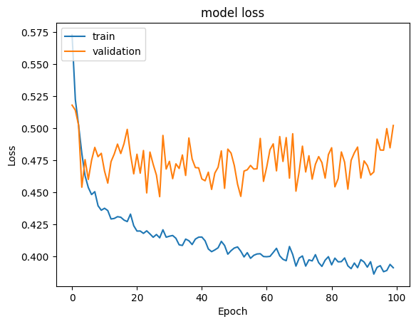

```python
#Plotting Train Loss vs Validation Loss
plt.plot(history_5.history['loss'])
plt.plot(history_5.history['val_loss'])
plt.title('model loss')
plt.ylabel('Loss')
plt.xlabel('Epoch')
plt.legend(['train', 'validation'], loc='upper left')
plt.show()
```

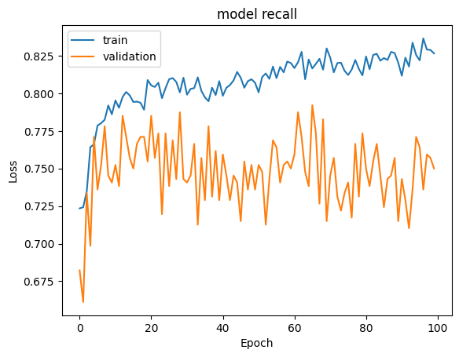

```python
#Plotting Train recall vs Validation recall
plt.plot(history_5.history['recall'])
plt.plot(history_5.history['val_recall'])
plt.title('model recall')
plt.ylabel('Loss')
plt.xlabel('Epoch')
plt.legend(['train', 'validation'], loc='upper left')
plt.show()
```

```python
y_train_pred = model_5.predict(X_train_smote)
#Predicting the results using 0.5 as the threshold
y_train_pred = (y_train_pred > 0.5)
y_train_pred
```

```
244/244 ━━━━━━━━━━━━━━━━━━━━ 0s 1ms/step
```

```
array([[False],
       [False],
       [False],
       ...,
       [ True],
       [ True],
       [ True]])
```

```python
y_val_pred = model_5.predict(X_val)
#Predicting the results using 0.5 as the threshold
y_val_pred = (y_val_pred > 0.5)
y_val_pred
```

```
66/66 ━━━━━━━━━━━━━━━━━━━━ 0s 1ms/step
```

```
array([[False],
       [False],
       [False],
       ...,
       [False],
       [ True],
       [ True]])
```

```python
model_name = "Neural Network with SMOTE,Adam & Dropout"

train_metric_df.loc[model_name] = recall_score(y_train_smote,y_train_pred)
valid_metric_df.loc[model_name] = recall_score(y_val,y_val_pred)
```

**Classification Report**

```python
cr=classification_report(y_train_smote,y_train_pred)
print(cr)
```

```
              precision    recall  f1-score   support

           0       0.89      0.80      0.84      3902
           1       0.82      0.90      0.86      3902

    accuracy                           0.85      7804
   macro avg       0.86      0.85      0.85      7804
weighted avg       0.86      0.85      0.85      7804
```

```python
#classification report
cr=classification_report(y_val,y_val_pred)
print(cr)
```

```
              precision    recall  f1-score   support

           0       0.92      0.74      0.82      1672
           1       0.43      0.75      0.55       428

    accuracy                           0.75      2100
   macro avg       0.68      0.75      0.68      2100
weighted avg       0.82      0.75      0.77      2100
```

**Training Set:** The model shows good performance with balanced precision, recall, and F1-scores for both classes, and an overall accuracy of 85%. This indicates effective learning from the training data.

**Confusion Matrix**

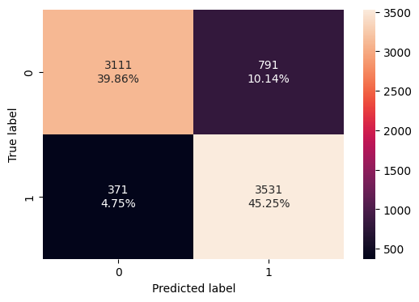

```python
#Calculating the confusion matrix
make_confusion_matrix(y_train_smote, y_train_pred)
```

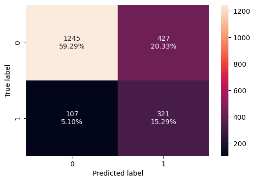

```python
#Calculating the confusion matrix
make_confusion_matrix(y_val,y_val_pred)
```

## Model Performance Comparison and Final Model Selection

```python
print("Training performance comparison")
train_metric_df
```

```
Training performance comparison
```

|  | recall |
| --- | --- |
| Neural Network with SGD | 0.167335 |
| Neural Network with Adam | 0.684369 |
| Neural Network with Adam & Dropout | 0.492986 |
| Neural Network with SMOTE & SGD | 0.736545 |
| Neural Network with SMOTE & Adam | 0.903127 |
| Neural Network with SMOTE,Adam & Dropout | 0.904921 |

```python
print("Validation set performance comparison")
valid_metric_df
```

```
Validation set performance comparison
```

|  | recall |
| --- | --- |
| Neural Network with SGD | 0.142523 |
| Neural Network with Adam | 0.544393 |
| Neural Network with Adam & Dropout | 0.500000 |
| Neural Network with SMOTE & SGD | 0.717290 |
| Neural Network with SMOTE & Adam | 0.742991 |
| Neural Network with SMOTE,Adam & Dropout | 0.750000 |

```python
train_metric_df - valid_metric_df
```

|  | recall |
| --- | --- |
| Neural Network with SGD | 0.024811 |
| Neural Network with Adam | 0.139976 |
| Neural Network with Adam & Dropout | -0.007014 |
| Neural Network with SMOTE & SGD | 0.019256 |
| Neural Network with SMOTE & Adam | 0.160136 |
| Neural Network with SMOTE,Adam & Dropout | 0.154921 |

**Training Set:** The combination of SMOTE, Adam, and Dropout achieved the highest recall (0.905), indicating the best performance in identifying the positive class during training.

```python
y_test_pred = model_5.predict(X_test)
y_test_pred = (y_test_pred > 0.5)
print(y_test_pred)
```

```
94/94 ━━━━━━━━━━━━━━━━━━━━ 0s 2ms/step
[[False]
 [False]
 [False]
 ...
 [ True]
 [ True]
 [False]]
```

```python
#lets print classification report
cr=classification_report(y_test,y_test_pred)
print(cr)
```

```
              precision    recall  f1-score   support

           0       0.93      0.75      0.83      2389
           1       0.44      0.77      0.56       611

    accuracy                           0.75      3000
   macro avg       0.68      0.76      0.69      3000
weighted avg       0.83      0.75      0.77      3000
```

**Test Data Insights**

**Class 0:** The model performs well with high precision (0.93) and a good recall (0.75), resulting in a strong F1-score of 0.83.

**Class 1:** The recall is high (0.77), but precision is lower (0.44), leading to a lower F1-score of 0.56. Overall, the model has a good accuracy of 75% and balances performance reasonably well across classes, with particularly strong precision for Class 0 and decent recall for Class 1.

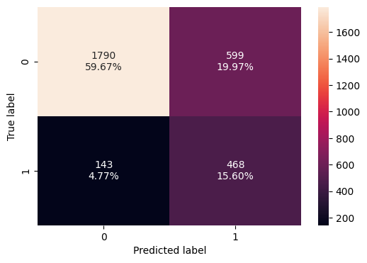

```python
#Calculating the confusion matrix
make_confusion_matrix(y_test,y_test_pred)
```

## Actionable Insights and Business Recommendations

**Age-Based Retention Strategies:**

**Insight:** Older customers are churning more than younger ones.

**Recommendation:** Review and tailor retention strategies to address the specific needs and preferences of older customers. This could involve:

**Customized Services:** Offering personalized services or products that cater to the preferences of older customers.

**Targeted Communication:** Developing targeted communication strategies to engage and retain older customers.

**Feedback Mechanisms:** Implementing feedback mechanisms to understand and address the concerns of older customers.

**Tenure-Based Retention Strategies:**

**Insight:** Clients with very short or long tenures are more likely to churn compared to those with average tenure.

**Recommendation:**

**Segmented Retention Programs:** Design retention programs for customers at different tenure stages, such as special incentives or offers for those who have been with the bank for a short or long period.

**Lifecycle Management:** Monitor customer lifecycle stages and proactively engage with those nearing the end of their tenure or who have recently joined.

**High-Balance Customers:**

**Insight:** Significant bank balance holders are churning, which could impact available capital for lending.

**Recommendation:**

**Exclusive Benefits:** Offer exclusive benefits or premium services to high-balance customers to enhance their loyalty.

**Personalized Outreach:** Increase personal engagement with high-balance customers to address their specific needs and concerns.

**Gender-Based Retention Strategies:**

**Insight:** A higher proportion of female customers are churning.

**Recommendation:**

**Gender-Specific Programs:** Develop targeted retention strategies or programs that address the needs and preferences of female customers.

**Customer Surveys:** Conduct surveys to understand why female customers are churning and tailor interventions accordingly.

**Credit Card Holders:**

**Insight:** Majority of churned customers have credit cards, but this might be coincidental given the high proportion of credit card holders.

**Recommendation:**

**Credit Card Usage Analysis:** Analyze credit card usage patterns and satisfaction levels. Consider offering loyalty rewards or enhanced features to credit card holders.

**Customer Segmentation:** Segment credit card holders based on their usage and satisfaction to identify at-risk customers.

**Inactive Members:**

**Insight:** Inactive members have a higher churn rate, and the proportion of inactive members is high.

**Recommendation:**

**Reactivation Programs:** Implement reactivation programs to convert inactive members into active ones. This could include:

**Special Offers:** Offering special promotions or incentives to inactive members to encourage them to become active.

**Engagement Campaigns:** Running engagement campaigns to re-engage inactive customers, such as targeted emails or personalized offers.

**Customer Experience Improvements:** Enhance the overall customer experience to reduce inactivity and improve retention.

**Conclusion**

By addressing these specific areas—age, tenure, balance, gender, credit card use, and inactivity—the bank can develop targeted strategies to improve customer retention and reduce churn. Implementing these recommendations will help in tailoring services and interventions to meet the needs of various customer segments, ultimately leading to better customer satisfaction and loyalty.

Power Ahead